# Part I - (Exploration of Loan Data from Prosper)

## Introduction

> **Loan Data from Prosper**
> - This data set contains 113,937 loans with 81 variables on each loan, including loan amount, borrower rate (or interest rate), current loan status, borrower income, and many others.

## Preliminary Wrangling

```python
# import all packages and set plots to be embedded inline
import numpy as np
import pandas as pd
import matplotlib.pyplot as plt
import seaborn as sns

%matplotlib inline
```

```python
df_loanData = pd.read_csv('prosperLoanData.csv')
```

```python
df_loanData.head()
```

|  | ListingKey | ListingNumber | ListingCreationDate | CreditGrade | Term | LoanStatus | ClosedDate | BorrowerAPR | BorrowerRate | LenderYield | ... | LP_ServiceFees | LP_CollectionFees | LP_GrossPrincipalLoss | LP_NetPrincipalLoss | LP_NonPrincipalRecoverypayments | PercentFunded | Recommendations | InvestmentFromFriendsCount | InvestmentFromFriendsAmount | Investors |
| --- | --- | --- | --- | --- | --- | --- | --- | --- | --- | --- | --- | --- | --- | --- | --- | --- | --- | --- | --- | --- | --- |
| 0 | 1021339766868145413AB3B | 193129 | 2007-08-26 19:09:29.263000000 | C | 36 | Completed | 2009-08-14 00:00:00 | 0.16516 | 0.1580 | 0.1380 | ... | -133.18 | 0.0 | 0.0 | 0.0 | 0.0 | 1.0 | 0 | 0 | 0.0 | 258 |
| 1 | 10273602499503308B223C1 | 1209647 | 2014-02-27 08:28:07.900000000 | NaN | 36 | Current | NaN | 0.12016 | 0.0920 | 0.0820 | ... | 0.00 | 0.0 | 0.0 | 0.0 | 0.0 | 1.0 | 0 | 0 | 0.0 | 1 |
| 2 | 0EE9337825851032864889A | 81716 | 2007-01-05 15:00:47.090000000 | HR | 36 | Completed | 2009-12-17 00:00:00 | 0.28269 | 0.2750 | 0.2400 | ... | -24.20 | 0.0 | 0.0 | 0.0 | 0.0 | 1.0 | 0 | 0 | 0.0 | 41 |
| 3 | 0EF5356002482715299901A | 658116 | 2012-10-22 11:02:35.010000000 | NaN | 36 | Current | NaN | 0.12528 | 0.0974 | 0.0874 | ... | -108.01 | 0.0 | 0.0 | 0.0 | 0.0 | 1.0 | 0 | 0 | 0.0 | 158 |
| 4 | 0F023589499656230C5E3E2 | 909464 | 2013-09-14 18:38:39.097000000 | NaN | 36 | Current | NaN | 0.24614 | 0.2085 | 0.1985 | ... | -60.27 | 0.0 | 0.0 | 0.0 | 0.0 | 1.0 | 0 | 0 | 0.0 | 20 |

5 rows × 81 columns

```python
df_loanData['Term'].value_counts()
```

```
36    87778
60    24545
12     1614
Name: Term, dtype: int64
```

- 871 records in the dataset have been duplicated
- ListingCreationDate and ClosedDate have incorrect data type
- Term variable is more of a category data type than a numerical type
- LoanStatus variable is more of a category data type than a object type representing a string
- ListingCategory (numeric) is more of a category data type than a numerical type

```python
#Check for duplicated records
df_loanData[df_loanData['ListingNumber'].duplicated() & df_loanData['ListingKey'].duplicated()]['ListingNumber'].size
```

```
871
```

```python
df_loanData.shape
```

```
(113937, 81)
```

### Data Cleaning

```python
# Make a copy of the original dataframe for cleaning purposes
df_copy = df_loanData.copy()
```

#### Issue 1:

> ListingCreationDate and ClosedDate have incorrect data type

#### Define:

- Convert data types of ListingCreationDate and ClosedDate to datetime

#### Code

```python
df_copy['ListingCreationDate'] = pd.to_datetime(df_copy['ListingCreationDate'])
df_copy['ClosedDate'] = pd.to_datetime(df_copy['ClosedDate'])
```

#### Test

```python
df_copy[['ListingCreationDate', 'ClosedDate']].info()
```

```
<class 'pandas.core.frame.DataFrame'>
RangeIndex: 113937 entries, 0 to 113936
Data columns (total 2 columns):
 #   Column               Non-Null Count   Dtype
---  ------               --------------   -----
 0   ListingCreationDate  113937 non-null  datetime64[ns]
 1   ClosedDate           55089 non-null   datetime64[ns]
dtypes: datetime64[ns](2)
memory usage: 1.7 MB
```

#### Issue 2:

> 871 records in the dataset have been duplicated

#### Define:

- Delete the 871 duplicated records

#### Code

```python
index = df_copy[df_copy['ListingNumber'].duplicated()].index
df_copy.drop(index, axis='rows', inplace=True)
```

#### Test

```python
df_copy[df_copy['ListingNumber'].duplicated()]
```

|  | ListingKey | ListingNumber | ListingCreationDate | CreditGrade | Term | LoanStatus | ClosedDate | BorrowerAPR | BorrowerRate | LenderYield | ... | LP_ServiceFees | LP_CollectionFees | LP_GrossPrincipalLoss | LP_NetPrincipalLoss | LP_NonPrincipalRecoverypayments | PercentFunded | Recommendations | InvestmentFromFriendsCount | InvestmentFromFriendsAmount | Investors |
| --- | --- | --- | --- | --- | --- | --- | --- | --- | --- | --- | --- | --- | --- | --- | --- | --- | --- | --- | --- | --- | --- |

0 rows × 81 columns

#### Issue 3:

> Term variable is more of a category data type than a numerical type

#### Define:

- Convert the Term column data type to ordered category data type

#### Code

```python
term_type = pd.CategoricalDtype(categories=[12, 36, 60], ordered=True)
df_copy['Term'] = df_copy['Term'].astype(term_type)
```

#### Test

```python
df_copy['Term'].info()
```

```
<class 'pandas.core.series.Series'>
Int64Index: 113066 entries, 0 to 113936
Series name: Term
Non-Null Count   Dtype
--------------   -----
113066 non-null  category
dtypes: category(1)
memory usage: 993.9 KB
```

#### Issue 4:

> LoanStatus variable is more of a category data type than a object type representing a string

#### Define:

- Convert the LoanStatus column data type to category data type

#### Code

```python
df_copy['LoanStatus']= df_copy['LoanStatus'].astype("category")
```

#### Test

```python
df_copy['LoanStatus'].info()
```

```
<class 'pandas.core.series.Series'>
Int64Index: 113066 entries, 0 to 113936
Series name: LoanStatus
Non-Null Count   Dtype
--------------   -----
113066 non-null  category
dtypes: category(1)
memory usage: 994.1 KB
```

#### Issue 5:

> ListingCategory (numeric) variable is more of a category data type than a object type representing a string

#### Define:

- Convert the ListingCategory (numeric) column data type to category data type

#### Code

```python
df_copy['ListingCategory (numeric)'] = df_copy['ListingCategory (numeric)'].astype('category')
```

#### Test

```python
df_copy['ListingCategory (numeric)'].info()
```

```
<class 'pandas.core.series.Series'>
Int64Index: 113066 entries, 0 to 113936
Series name: ListingCategory (numeric)
Non-Null Count   Dtype
--------------   -----
113066 non-null  category
dtypes: category(1)
memory usage: 994.5 KB
```

```python
df_copy['ProsperRating (numeric)'].info()
```

[output not shown]

#### Issue 6:

> ProsperRating (numeric) variable is more of a category data type than a float64.

#### Define:

- Convert the ProsperRating (numeric) column data type to category data type

#### Code

```python
def convert_prosperRating():
    """Convert the ProsperRating (numeric) column data type to ordered category data type"""
    prosper_type = pd.CategoricalDtype(categories=[1, 2, 3, 4, 5, 6, 7], ordered=True)
    df_copy['ProsperRating (numeric)'] = df_copy['ProsperRating (numeric)'].astype(prosper_type)
```

```python
#Convert the ProsperRating (numeric) column data type to ordered category data type
convert_prosperRating()
```

#### Test

```python
df_copy['ProsperRating (numeric)'].info()
```

```
<class 'pandas.core.series.Series'>
Int64Index: 113066 entries, 0 to 113936
Series name: ProsperRating (numeric)
Non-Null Count  Dtype
--------------  -----
83982 non-null  category
dtypes: category(1)
memory usage: 994.1 KB
```

```python
#Store cleaned data in csv file
df_copy.to_csv('clean_data.csv')
```

### The structure of the dataset

> The prosperLoanData Dataset has 113,937 rows and 81 columns.

### The main feature of interest in the dataset

> 'LoanOriginalAmount'
> - Are there differences between loans depending on how large the original loan amount was?

### Features in the dataset that will help support the investigation into the feature of interest

> 'Term', 'LoanStatus', 'BorrowerRate', 'BorrowerState', 'EmploymentStatus', 'LoanOriginalAmount', 'CreditScoreRangeLower', 'DebtToIncomeRatio', 'IncomeRange', 'AmountDelinquent', 'AvailableBankcardCredit'

## Univariate Exploration

### What is the distribution of the LoanOriginalAmount feature?

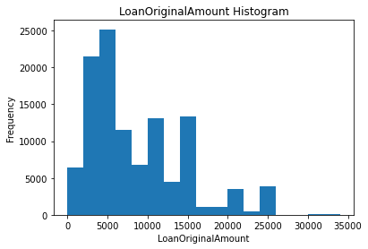

```python
#plot a histogram to showcase the distribution of LoanOriginalAmount
bins = np.arange(0, df_copy['LoanOriginalAmount'].max()+10, 2000)
plt.hist(data=df_copy, x='LoanOriginalAmount', bins=bins);
plt.title('LoanOriginalAmount Histogram')
plt.xlabel('LoanOriginalAmount')
plt.ylabel('Frequency');
```

- The distribution of the LoanOriginalAmount is right skewed with most loan amount between 2000 and 15000.

### What is the distribution of the BorrowerRate feature?

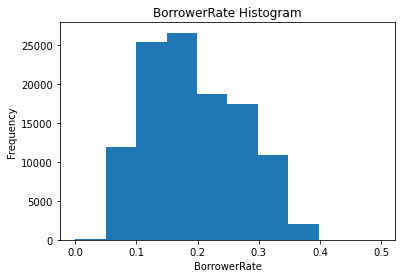

```python
#plot a histogram to showcase the distribution of BorrowerRate
bins = np.arange(0, df_copy['BorrowerRate'].max()+0.5, 0.05)
plt.hist(data=df_copy, x='BorrowerRate');
plt.title('BorrowerRate Histogram')
plt.xlabel('BorrowerRate')
plt.ylabel('Frequency');
```

- The distribution of the BorrowerRate feature is right skewed with most rates between 0.1 and 0.3.

### What is the distribution of the AmountDelinquent feature?

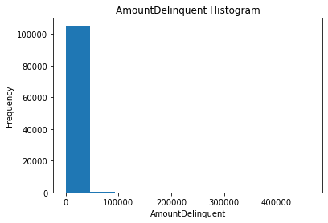

```python
#plot a histogram to showcase the distribution of AmountDelinquent
plt.hist(data=df_copy, x='AmountDelinquent');
plt.title('AmountDelinquent Histogram')
plt.xlabel('AmountDelinquent')
plt.ylabel('Frequency');
```

```python
print(len(df_copy))
len(df_copy[df_copy['AmountDelinquent']>100000])
```

```
113066
```

```
112
```

- The distribution of the AmountDelinquent feature is right skewed. The histogram also depict presence of outlier AmountDelinquent values. Out of 113066 values, 112 AmountDelinquent values range above 100000.

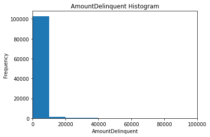

```python
#plot a histogram to showcase the distribution of AmountDelinquent

bins = np.arange(0, df_copy['AmountDelinquent'].max()+5, 10000)
plt.hist(data=df_copy, x='AmountDelinquent',bins=bins)
plt.xlim(0, 100000)
plt.title('AmountDelinquent Histogram')
plt.xlabel('AmountDelinquent')
plt.ylabel('Frequency');
```

- Zooming in on the distribution of the AmountDelinquent feature depicts that majority of the data points are between 0 and 20,000.

### What is the distribution of the AvailableBankcardCredit feature?

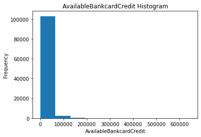

```python
#plot a histogram to showcase the distribution of AvailableBankcardCredit
bins = np.arange(0, df_copy['AvailableBankcardCredit'].max()+0.5, 0.05)
plt.hist(data=df_copy, x='AvailableBankcardCredit')
plt.title('AvailableBankcardCredit Histogram')
plt.xlabel('AvailableBankcardCredit')
plt.ylabel('Frequency');
```

```python
print(len(df_copy))
len(df_copy[df_copy['AvailableBankcardCredit']>200000])
```

```
113066
```

```
89
```

- The distribution of the AvailableBankcardCredit feature is right skewed. The histogram also depict presence of outlier AvailableBankcardCredit values. Out of 113066 values, 89 AvailableBankcardCredit values range above 200000.

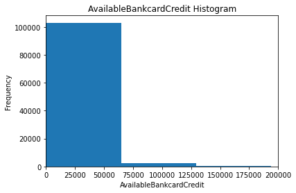

```python
#plot a histogram to showcase the distribution of AvailableBankcardCredit
bins = np.arange(0, df_copy['AvailableBankcardCredit'].max(), 20000)
plt.hist(data=df_copy, x='AvailableBankcardCredit')
plt.xlim(0, 200000)
plt.title('AvailableBankcardCredit Histogram')
plt.xlabel('AvailableBankcardCredit')
plt.ylabel('Frequency');
```

- Zooming in on the distribution of the AvailableBankcardCredit feature depicts that majority of the data points are between 0 and 60,000

### What is the distribution of the CreditScoreRangeLower feature?

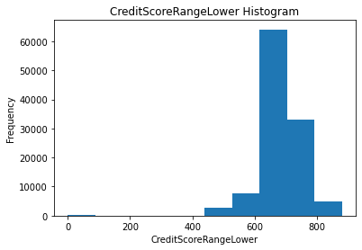

```python
#plot a histogram to showcase the distribution of CreditScoreRangeLower
bins = np.arange(0, df_copy['CreditScoreRangeLower'].max()+10, 2000)
plt.hist(data=df_copy, x='CreditScoreRangeLower');
plt.title('CreditScoreRangeLower Histogram')
plt.xlabel('CreditScoreRangeLower')
plt.ylabel('Frequency');
```

### What is the distribution of the DebtToIncomeRatio feature?

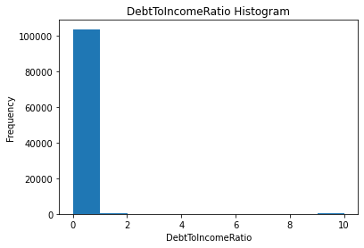

```python
#plot a histogram to showcase the distribution of DebtToIncomeRatio
bins = np.arange(0, df_copy['DebtToIncomeRatio'].max()+10, 2000)
plt.hist(data=df_copy, x='DebtToIncomeRatio');
plt.title('DebtToIncomeRatio Histogram')
plt.xlabel('DebtToIncomeRatio')
plt.ylabel('Frequency');
```

- The distribution of the DebtToIncomeRatio feature is right skewed. The histogram also depict presence of outlier DebtToIncomeRatio values between 9 and 10.

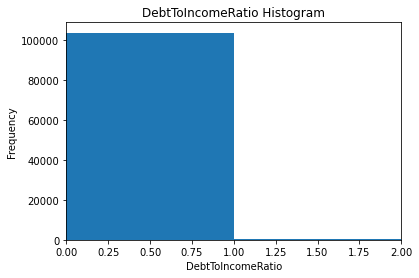

```python
#plot a histogram to showcase the distribution of DebtToIncomeRatio
bins = np.arange(0, df_copy['DebtToIncomeRatio'].max()+10, 2000)
plt.hist(data=df_copy, x='DebtToIncomeRatio')
plt.xlim(0, 2)
plt.title('DebtToIncomeRatio Histogram')
plt.xlabel('DebtToIncomeRatio')
plt.ylabel('Frequency');
```

- Zooming in on the distribution of the DebtToIncomeRatio feature depicts that majority of the data points are between 0 and 1.

### What is the distribution of the Term feature?

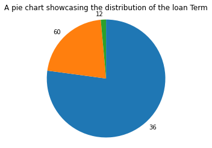

```python
#plot a pie chart to showcase the distribution of Term of the loan
sorted_counts = df_copy['Term'].value_counts()
plt.pie(sorted_counts, labels = sorted_counts.index, startangle = 90, counterclock = False);
plt.axis('square')
plt.title('A pie chart showcasing the distribution of the loan Term');
```

- Majority of the loans i.e more than 3/4 have a loan term of `36` months. The `12` months loan term category had the least number of loans with 1614 out of 113066.

```python
print(len(df_copy))
df_copy['Term'].value_counts()
```

```
113066
```

```
36    87224
60    24228
12     1614
Name: Term, dtype: int64
```

### What is the distribution of the IncomeRange feature?

```python
df_copy['IncomeRange'].unique()
```

```
array(['$25,000-49,999', '$50,000-74,999', 'Not displayed', '$100,000+',
       '$75,000-99,999', '$1-24,999', 'Not employed', '$0'], dtype=object)
```

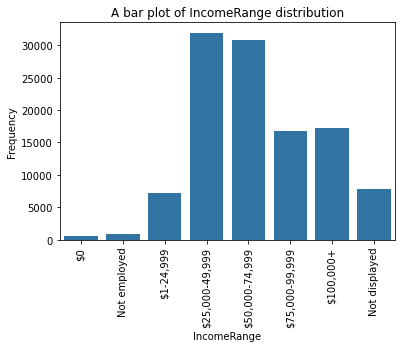

```python
#Convert the IncomeRange column data type to ordered category data type
income_type = pd.CategoricalDtype(categories=['$0', 'Not employed', '$1-24,999', '$25,000-49,999', '$50,000-74,999', '$75,000-99,999', '$100,000+', 'Not displayed'], ordered=True)
df_copy['IncomeRange'] = df_copy['IncomeRange'].astype(income_type)
#plot a bar plot to showcase the distribution of IncomeRange
base_color = sns.color_palette()[0]
sns.countplot(data=df_copy, x='IncomeRange', color=base_color)
plt.xticks(rotation=90)
plt.ylabel('Frequency')
plt.title('A bar plot of IncomeRange distribution');
```

- The `$25,000-49,999` and `$50,000-74,999` IncomeRange categories had the highest distributions whereas `$0`, and `Not employed` IncomeRange categories had the least distributions.

### What is the distribution of the LoanStatus feature?

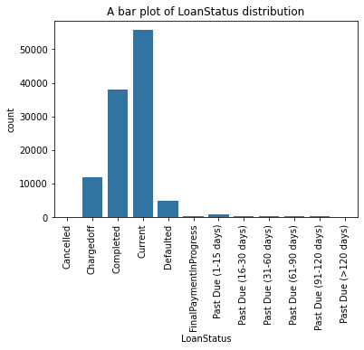

```python
#plot a bar plot to showcase the distribution of LoanStatus
sns.countplot(data=df_copy, x="LoanStatus", color=base_color)
plt.xticks(rotation=90)
plt.title('A bar plot of LoanStatus distribution');
```

- In regards to the LoanStatus feature most loans in this dataset are either current or completed with a few either chargedoff, defaulted, in final payment, past due or cancelled.

```python
df_copy[df_copy['LoanStatus'] != 'Current']['LoanStatus'].value_counts()
```

```
Completed                 38061
Chargedoff                11992
Defaulted                  5018
Past Due (1-15 days)        800
Past Due (31-60 days)       361
Past Due (61-90 days)       311
Past Due (91-120 days)      304
Past Due (16-30 days)       265
FinalPaymentInProgress      203
Past Due (>120 days)         16
Cancelled                     5
Name: LoanStatus, dtype: int64
```

### What is the distribution of the EmploymentStatus feature?

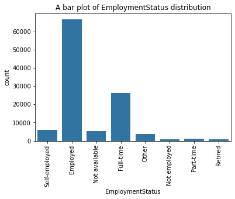

```python
#plot a bar plot to showcase the distribution of EmploymentStatus
sns.countplot(data=df_copy, x="EmploymentStatus", color=base_color)
plt.xticks(rotation=90)
plt.title('A bar plot of EmploymentStatus distribution');
```

- In the EmploymentStatus feature, the `Employed` category has significant higher distribution compared to other EmploymentStatus categories followed by the `Full-time` category. The `Not-employed`, `Part-time` and `Retired` categories had the least distributions.

### What is the distribution of the ProsperRating (numeric) feature?

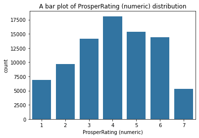

```python
#Convert the ProsperRating (numeric) column data type to ordered category data type
prosper_type = pd.CategoricalDtype(categories=[1, 2, 3, 4, 5, 6, 7], ordered=True)
df_copy['ProsperRating (numeric)'] = df_copy['ProsperRating (numeric)'].astype(prosper_type)
#plot a bar plot to showcase the distribution of ProsperRating (numeric)
sns.countplot(data=df_copy, x="ProsperRating (numeric)", color=base_color)
plt.title('A bar plot of ProsperRating (numeric) distribution');
```

- The distribution of ProsperRating (numeric) feature increases from the first and least rating to the middle rating and subsequently decreases from the miiddle to last and highest rating.

### Of the features you investigated, were there any unusual distributions? Did you perform any operations on the data to tidy, adjust, or change the form of the data? If so, why did you do this?

- The AmountDelinquent feature histogram depicts presence of outlier AmountDelinquent values. Out of 113066 values, 112 AmountDelinquent values range above 100000. Zooming in on the distribution of the AmountDelinquent feature depicts that majority of the data points are between 0 and 20,000.
- The AvailableBankcardCredit feature histogram depicts presence of outlier AvailableBankcardCredit values. Out of 113066 values, 89 AvailableBankcardCredit values range above 200000. Zooming in on the distribution of the AvailableBankcardCredit feature depicts that majority of the data points are between 0 and 60,000.
- ProsperRating (numeric) variable is more of a category data type than a float64. therefore I converted the ProsperRating (numeric) column data type and plotted it as a category data type

## Bivariate Exploration

### How does the LoanOriginalAmount feature relate to BorrowerRate feature?

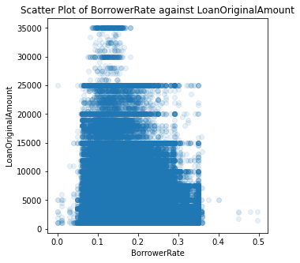

```python
#plot a scatter plot of LoanOriginalAmount against BorrowerRate
plt.figure(figsize=(5,5))
plt.scatter(data=df_copy, x='BorrowerRate', y='LoanOriginalAmount', alpha=1/10)
plt.xlabel('BorrowerRate')
plt.ylabel('LoanOriginalAmount')
plt.title('Scatter Plot of BorrowerRate against LoanOriginalAmount');
```

- In regards to the relation betweeen LoanOriginalAmount and BorrowerRate, few Loan Amounts of 3000 and below had BorrowerRate of greater than 0.4. Loan Amounts of above 25000 had BorrowerRate of below 0.2.

### How does the LoanOriginalAmount feature relate to CreditScoreRangeLower feature?

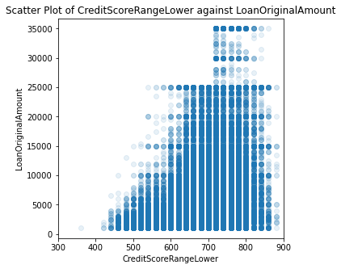

```python
#plot a scatter plot of LoanOriginalAmount against CreditScoreRangeLower
plt.figure(figsize=(5,5))
plt.scatter(data=df_copy, x='CreditScoreRangeLower', y='LoanOriginalAmount', alpha=1/10)
plt.xlim(300, 900)
plt.xlabel('CreditScoreRangeLower')
plt.ylabel('LoanOriginalAmount')
plt.title('Scatter Plot of CreditScoreRangeLower against LoanOriginalAmount');
```

- Considering the relation between LoanOriginalAmount and CreditScoreRangeLower, most loan amounts CreditScoreRangeLower lie between 360 and 880. Loan Amounts of above 25000 associate with scores of 720 and above. A few Loan amounts have CreditScoreRangeLower of 0.

### How does the LoanOriginalAmount feature relate to DebtToIncomeRatio feature?

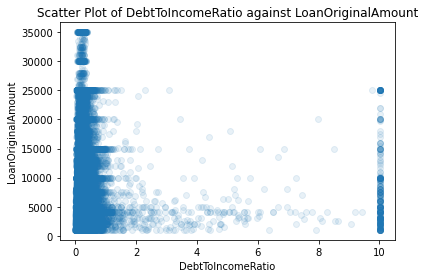

```python
#plot a scatter plot of LoanOriginalAmount against DebtToIncomeRatio
#plt.figure(figsize=(5,5))
plt.scatter(data=df_copy, x='DebtToIncomeRatio', y='LoanOriginalAmount', alpha=1/10)
plt.xlabel('DebtToIncomeRatio')
plt.ylabel('LoanOriginalAmount')
plt.title('Scatter Plot of DebtToIncomeRatio against LoanOriginalAmount');
```

- Relating DebtToIncomeRatio to LoanOriginalAmount, we observe that loan amounts above 25000 have low DebtToIncomeRatio of not more than 0.4 compared to other lower loan amounts. Most Loan amounts, regardless of the amount, have a DebtToIncomeRatio of between 0 and 1.

### How does the LoanOriginalAmount feature relate to AmountDelinquent feature?

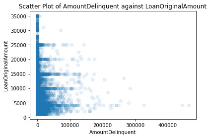

```python
#plot a scatter plot of LoanOriginalAmount against AmountDelinquent
#plt.figure(figsize=(5,5))
plt.scatter(data=df_copy, x='AmountDelinquent', y='LoanOriginalAmount', alpha=1/10)
plt.xlabel('AmountDelinquent')
plt.ylabel('LoanOriginalAmount')
plt.title('Scatter Plot of AmountDelinquent against LoanOriginalAmount');
```

- Given that most loan amounts above 25,000 are current, only 2 were delinquent with 18,239 and 70,734. 3 loan amounts of 4000 stood out with AmountDelinquent of above 300,000 and 400,000
- Most loan amounts have AmountDelinquent of less than 30,000

### How does the LoanOriginalAmount feature relate to AvailableBankcardCredit feature?

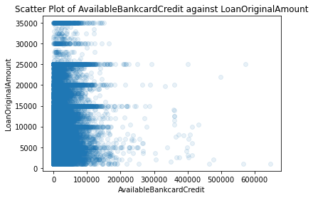

```python
#plot a scatter plot of LoanOriginalAmount against AvailableBankcardCredit
#plt.figure(figsize=(5,5))
plt.scatter(data=df_copy, x='AvailableBankcardCredit', y='LoanOriginalAmount', alpha=1/10)
plt.xlabel('AvailableBankcardCredit')
plt.ylabel('LoanOriginalAmount')
plt.title('Scatter Plot of AvailableBankcardCredit against LoanOriginalAmount');
```

- Most LoanOriginalAmounts have AvailableBankcardCredit of less than 100,000. Compared to low amounts, LoanOriginalAmounts of above 25000 do not have AvailableBankcardCredit greater than 200,000.

### How does the LoanOriginalAmount feature relate to EmploymentStatus feature?

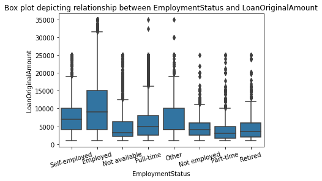

```python
#plot a box plot depicting relationship between EmploymentStatus and LoanOriginalAmount
base_color = sns.color_palette()[0]
sns.boxplot(data=df_copy, x='EmploymentStatus', y='LoanOriginalAmount', color=base_color)
plt.xticks(rotation=15);
plt.xlabel('EmploymentStatus')
plt.ylabel('LoanOriginalAmount');
plt.title('Box plot depicting relationship between EmploymentStatus and LoanOriginalAmount');
```

- Generally borrowers in the Employed category have higher loan amounts.
- Loan amounts above 25000 were issued to the Employed, Full-time and other categories.

### How does the LoanOriginalAmount feature relate to IncomeRange feature?

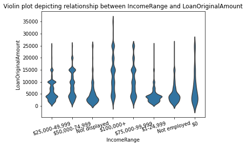

```python
#plot a Violin plot depicting relationship between IncomeRange and LoanOriginalAmount
base_color = sns.color_palette()[0]
sns.violinplot(data=df_copy, x='IncomeRange', y='LoanOriginalAmount', color=base_color, inner=None)
plt.xticks(rotation=15)
plt.xlabel('IncomeRange')
plt.ylabel('LoanOriginalAmount');
plt.title('Violin plot depicting relationship between IncomeRange and LoanOriginalAmount');
```

- Most loan amounts above `25,000` were issued to borrowers in the largest income-range category of `100,000+`
- The `$0`, `Not employed`, `1-24,999`, `25,000-49,999` and `Not displayed` categories have relatively higher distribution of lower loan amounts of less than 7000.

### How does the LoanOriginalAmount feature relate to ProsperRating (numeric) feature?

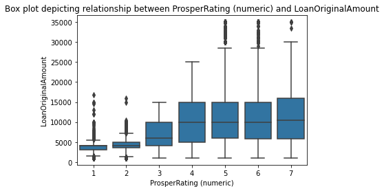

```python
#plot a box plot depicting relationship between ProsperRating (numeric) and LoanOriginalAmount
base_color = sns.color_palette()[0]
sns.boxplot(data=df_copy, x='ProsperRating (numeric)', y='LoanOriginalAmount', color=base_color)
plt.xlabel('ProsperRating (numeric)')
plt.ylabel('LoanOriginalAmount');
plt.title('Box plot depicting relationship between ProsperRating (numeric) and LoanOriginalAmount');
```

- Borrowers of loans above `25,000` are in the `7`, `6` and `5` of ProsperRating (numeric) categories. `1`, `2` and `3` categories had the least highest amounts.

### How does the ProsperRating (numeric) feature relate to BorrowerRate feature?

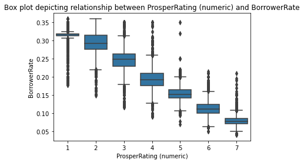

```python
#plot a box plot depicting relationship between ProsperRating (numeric) and BorrowerRate
base_color = sns.color_palette()[0]
sns.boxplot(data=df_copy, x='ProsperRating (numeric)', y='BorrowerRate', color=base_color)
plt.xlabel('ProsperRating (numeric)')
plt.ylabel('BorrowerRate')
plt.title('Box plot depicting relationship between ProsperRating (numeric) and BorrowerRate');
```

- The Box plot depicting relationship between ProsperRating (numeric) and BorrowerRate showcases that the general trend is that the higher the `ProsperRating (numeric)` the lower the `BorrowerRate`.

### How does the LoanOriginalAmount feature relate to Term feature?

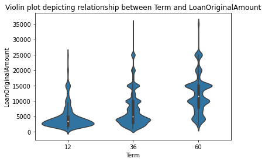

```python
#plot a Violin plot depicting relationship between Term and LoanOriginalAmount
sns.violinplot(data=df_copy, x='Term', y='LoanOriginalAmount', color=base_color)
plt.title('Violin plot depicting relationship between Term and LoanOriginalAmount');
```

- Term `12` and `36` have higher distribution of lower loan amounts of 5000 and below compared to Term `60` which has higher distribution of higher loan amounts of 10,000 and above.

### Talk about some of the relationships you observed in this part of the investigation. How did the feature(s) of interest vary with other features in the dataset?

- In regards to the relation betweeen LoanOriginalAmount and BorrowerRate, few Loan Amounts of 3000 and below had BorrowerRate of greater than 0.4. Loan Amounts of above 25000 had BorrowerRate of below 0.2.
- Considering the relation between LoanOriginalAmount and CreditScoreRangeLower, most loan amounts CreditScoreRangeLower lie between 360 and 880. Loan Amounts of above 25000 associate with scores of 720 and above. A few Loan amounts have CreditScoreRangeLower of 0.
- Relating DebtToIncomeRatio to LoanOriginalAmount, we observe that loan amounts above 25000 have low DebtToIncomeRatio of not more than 0.4 compared to other lower loan amounts. Most Loan amounts, regardless of the amount, have a DebtToIncomeRatio of between 0 and 1.
- Given that most loan amounts above 25,000 are current, only 2 were delinquent with 18,239 and 70,734. 3 loan amounts of 4000 stood out with AmountDelinquent of above 300,000 and 400,000. Most loan amounts have AmountDelinquent of less than 30,000.
- Most LoanOriginalAmounts have AvailableBankcardCredit of less than 100,000. Compared to low amounts, LoanOriginalAmounts of above 25000 do not have AvailableBankcardCredit greater than 200,000.
- Considering the relation between LoanOriginalAmount and EmploymentStatus, generally borrowers in the Employed category have higher loan amounts. Loan amounts above 25000 were issued to the Employed, Full-time and other categories.
- Most loan amounts above `25,000` were issued to borrowers in the largest income-range category of `100,000+`. The `$0`, `Not employed`, `1-24,999`, `25,000-49,999` and `Not displayed` categories have relatively higher distribution of lower loan amounts of less than 7000.
- Borrowers of loans above `25,000` are in the `7`, `6` and `5` of ProsperRating (numeric) categories. `1`, `2` and `3` categories had the least highest amounts.

### Did you observe any interesting relationships between the other features (not the main feature(s) of interest)?

- The Box plot depicting relationship between ProsperRating (numeric) and BorrowerRate showcases that the general trend is that the higher the `ProsperRating (numeric)` the lower the `BorrowerRate`.

## Multivariate Exploration

### How do the `IncomeRange`, `BorrowerRate`, and `LoanOriginalAmount` features interact with each other?

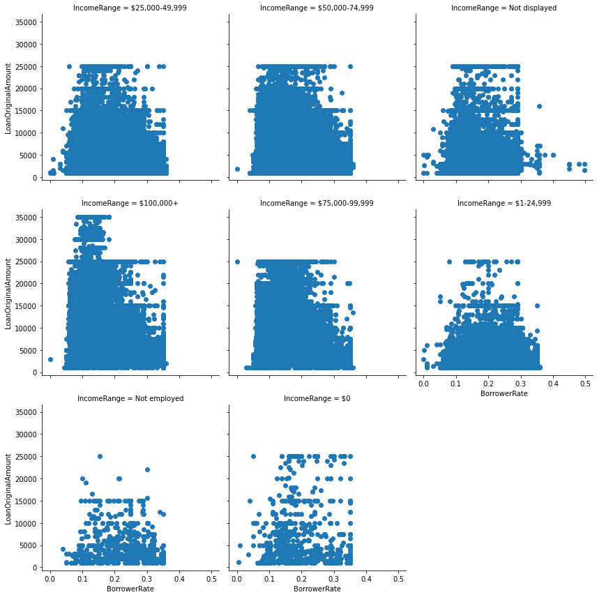

```python
#plot scatter plots of BorrowerRate against LoanOriginalAmount and facet using the IncomeRange feature
g = sns.FacetGrid(data = df_copy, col = 'IncomeRange', height = 4, col_wrap=3)
g.map(plt.scatter, 'BorrowerRate', 'LoanOriginalAmount');
```

- Ploting scatter plots of BorrowerRate against LoanOriginalAmount and faceting using the IncomeRange feature depicts the `100000+` and the `Not displayed` IncomeRange categories as being significantly different from the other IncomeRange categories.
- The `100000+` IncomeRange category is the one that only contains loan amounts above 25000 in addition to other lower amounts.
- The `Not displayed` IncomeRange category contains the loan amounts that have the highest BorrowerRate compared to loan amounts in other IncomeRange categories.

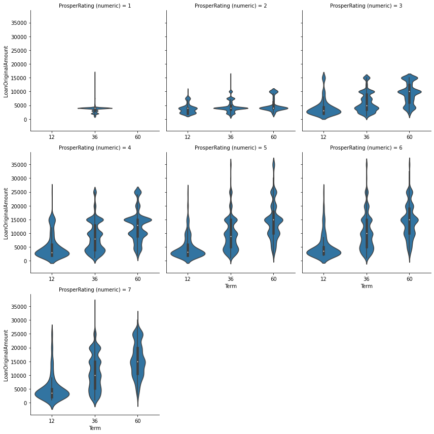

```python
#plot a violinplot of Term against LoanOriginalAmount and facet using the LoanStatus feature
g = sns.FacetGrid(data = df_copy, col = 'ProsperRating (numeric)', height = 4, col_wrap=3, sharex=False)
g.map(sns.violinplot, 'Term', 'LoanOriginalAmount');
```

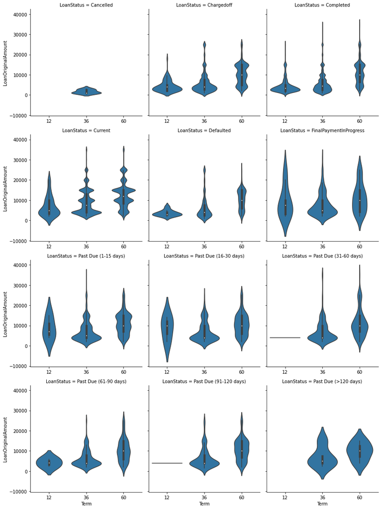

```python
#plot a violinplot of Term against LoanOriginalAmount and facet using the LoanStatus feature
g = sns.FacetGrid(data = df_copy, col = 'LoanStatus', height = 4, col_wrap=3, sharex=False)
g.map(sns.violinplot, 'Term', 'LoanOriginalAmount');
```

### How do the `ProsperRating (numeric)`, `BorrowerRate`, and `LoanOriginalAmount` features interact with each other?

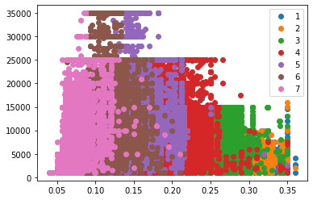

```python
#plot a scatter plot of BorrowerRate against LoanOriginalAmount and encode the
#ProsperRating (numeric) using color.
groups = df_copy.groupby('ProsperRating (numeric)')
for name, group in groups:
    plt.plot(group.BorrowerRate, group.LoanOriginalAmount, marker='o', linestyle='', markersize=6, label=name)
plt.legend()
```

- Across various amounts of the `LoanOriginalAmount` feature the `BorrowerRate` increases with the decrease in `ProsperRating (numeric)`.

### Talk about some of the relationships you observed in this part of the investigation. Were there features that strengthened each other in terms of looking at your feature(s) of interest?

- Ploting scatter plots of BorrowerRate against LoanOriginalAmount and faceting using the IncomeRange feature depicts the `100000+` and the `Not displayed` IncomeRange categories as being significantly different from the other IncomeRange categories. The `100000+` IncomeRange category is the one that only contains loan amounts above 25000 in addition to other lower amounts. The `Not displayed` IncomeRange category contains the loan amounts that have the highest BorrowerRate compared to loan amounts in other IncomeRange categories.

### Were there any interesting or surprising interactions between features?

- Across various amounts of the `LoanOriginalAmount` feature the `BorrowerRate` increases with the decrease in `ProsperRating (numeric)`.

## Conclusions

- The distribution of the LoanOriginalAmount is right skewed with most loan amount between 2000 and 15000.
- In regards to the relation betweeen LoanOriginalAmount and BorrowerRate, few Loan Amounts of 3000 and below had BorrowerRate of greater than 0.4. Loan Amounts of above 25000 had BorrowerRate of below 0.2.
- Considering the relation between LoanOriginalAmount and CreditScoreRangeLower, most loan amounts CreditScoreRangeLower lie between 360 and 880. Loan Amounts of above 25000 associate with scores of 720 and above. A few Loan amounts have CreditScoreRangeLower of 0.
- Relating DebtToIncomeRatio to LoanOriginalAmount, we observe that loan amounts above 25000 have low DebtToIncomeRatio of not more than 0.4 compared to other lower loan amounts. Most Loan amounts, regardless of the amount, have a DebtToIncomeRatio of between 0 and 1.
- Given that most loan amounts above 25,000 are current, only 2 were delinquent with 18,239 and 70,734. 3 loan amounts of 4000 stood out with AmountDelinquent of above 300,000 and 400,000. Most loan amounts have AmountDelinquent of less than 30,000.
- Most LoanOriginalAmounts have AvailableBankcardCredit of less than 100,000. Compared to low amounts, LoanOriginalAmounts of above 25000 do not have AvailableBankcardCredit greater than 200,000.
- Considering the relation between LoanOriginalAmount and EmploymentStatus, generally borrowers in the Employed category have higher loan amounts. Loan amounts above 25000 were issued to the Employed, Full-time and other categories.
- Most loan amounts above `25,000` were issued to borrowers in the largest income-range category of `100,000+`. The `$0`, `Not employed`, `1-24,999`, `25,000-49,999` and `Not displayed` categories have relatively higher distribution of lower loan amounts of less than 7000.
- Borrowers of loans above `25,000` are in the `7`, `6` and `5` of ProsperRating (numeric) categories. `1`, `2` and `3` categories had the least highest amounts.
- The Box plot depicting relationship between ProsperRating (numeric) and BorrowerRate showcases that the general trend is that the higher the `ProsperRating (numeric)` the lower the `BorrowerRate`.
- Ploting scatter plots of BorrowerRate against LoanOriginalAmount and faceting using the IncomeRange feature depicts the `100000+` and the `Not displayed` IncomeRange categories as being significantly different from the other IncomeRange categories. The `100000+` IncomeRange category is the one that only contains loan amounts above 25000 in addition to other lower amounts. The `Not displayed` IncomeRange category contains the loan amounts that have the highest BorrowerRate compared to loan amounts in other IncomeRange categories.
- Across various amounts of the `LoanOriginalAmount` feature the `BorrowerRate` increases with the decrease in `ProsperRating (numeric)`.